# Exploratory Data Analysis on Quality Red Wines by Teresa E. Upshaw

The data set used for the analysis contains 1,599 red wines with 11 variables on the chemical properties of red wine. It also contains a quality rating for each wine with a score between 0 and 10 which was rated by at least 3 wine experts.

Let’s take a peak at the first 5 rows of data.

```
##   X fixed.acidity volatile.acidity citric.acid residual.sugar chlorides
## 1 1           7.4             0.70        0.00            1.9     0.076
## 2 2           7.8             0.88        0.00            2.6     0.098
## 3 3           7.8             0.76        0.04            2.3     0.092
## 4 4          11.2             0.28        0.56            1.9     0.075
## 5 5           7.4             0.70        0.00            1.9     0.076
##   free.sulfur.dioxide total.sulfur.dioxide density   pH sulphates alcohol
## 1                  11                   34  0.9978 3.51      0.56     9.4
## 2                  25                   67  0.9968 3.20      0.68     9.8
## 3                  15                   54  0.9970 3.26      0.65     9.8
## 4                  17                   60  0.9980 3.16      0.58     9.8
## 5                  11                   34  0.9978 3.51      0.56     9.4
##   quality
## 1       5
## 2       5
## 3       5
## 4       6
## 5       5
```

For this analysis project, I will analyze the Red Wine Data and try to determine which variables influence the quality of red wine. First I will look at the variables individually and then try to find out if a correlation exist between them and quality.

A quick summary of the data shows that approximately 80% of red wines have a quality rating of average or good. Now for the hard part, let’s determine which chemical properties make for a good bottle of wine.

```
##    Min. 1st Qu.  Median    Mean 3rd Qu.    Max.
##   3.000   5.000   6.000   5.636   6.000   8.000
```

```
##
##  very bad       bad   average      good     great excellent
##        10        53       681       638       199        18
```

The graph below reinforces the previous summary chart and shows that most of the wines in our data set are in the average to good range.

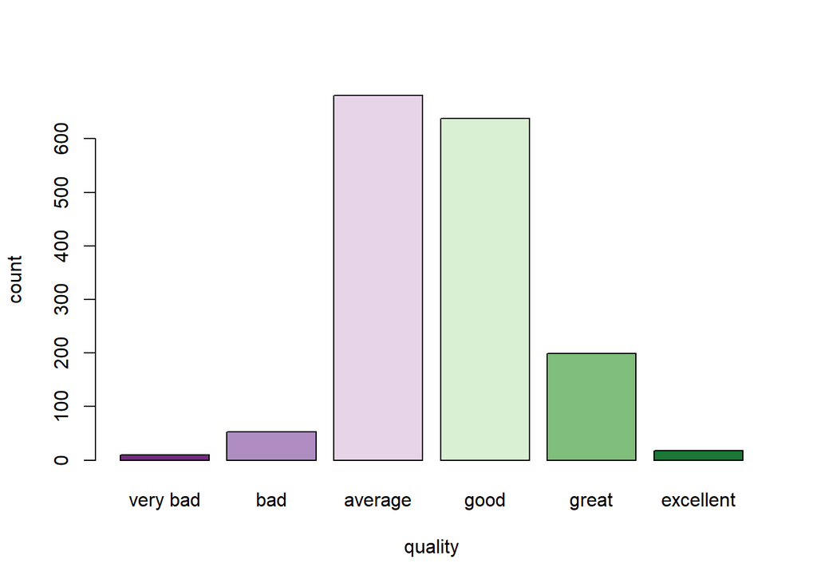

# Univariate Plots Section

The summary table below summarizes and provides information about our data. It tells you something about the values in your data set. It shows where the beginning (min), the middle(median), and end (max) lies. It also give info on where the variables boundaries for the lowest, middle and upper quarters of data resides (quartile).

Here is a list of all the variables along with a summary:

```
##  [1] "fixed.acidity"        "volatile.acidity"     "citric.acid"
##  [4] "residual.sugar"       "chlorides"            "free.sulfur.dioxide"
##  [7] "total.sulfur.dioxide" "density"              "pH"
## [10] "sulphates"            "alcohol"              "quality"
## [13] "quality.rating"
```

```
##  fixed.acidity   volatile.acidity  citric.acid    residual.sugar
##  Min.   : 4.60   Min.   :0.1200   Min.   :0.000   Min.   : 0.900
##  1st Qu.: 7.10   1st Qu.:0.3900   1st Qu.:0.090   1st Qu.: 1.900
##  Median : 7.90   Median :0.5200   Median :0.260   Median : 2.200
##  Mean   : 8.32   Mean   :0.5278   Mean   :0.271   Mean   : 2.539
##  3rd Qu.: 9.20   3rd Qu.:0.6400   3rd Qu.:0.420   3rd Qu.: 2.600
##  Max.   :15.90   Max.   :1.5800   Max.   :1.000   Max.   :15.500
##    chlorides       free.sulfur.dioxide total.sulfur.dioxide
##  Min.   :0.01200   Min.   : 1.00       Min.   :  6.00
##  1st Qu.:0.07000   1st Qu.: 7.00       1st Qu.: 22.00
##  Median :0.07900   Median :14.00       Median : 38.00
##  Mean   :0.08747   Mean   :15.87       Mean   : 46.47
##  3rd Qu.:0.09000   3rd Qu.:21.00       3rd Qu.: 62.00
##  Max.   :0.61100   Max.   :72.00       Max.   :289.00
##     density             pH          sulphates         alcohol
##  Min.   :0.9901   Min.   :2.740   Min.   :0.3300   Min.   : 8.40
##  1st Qu.:0.9956   1st Qu.:3.210   1st Qu.:0.5500   1st Qu.: 9.50
##  Median :0.9968   Median :3.310   Median :0.6200   Median :10.20
##  Mean   :0.9967   Mean   :3.311   Mean   :0.6581   Mean   :10.42
##  3rd Qu.:0.9978   3rd Qu.:3.400   3rd Qu.:0.7300   3rd Qu.:11.10
##  Max.   :1.0037   Max.   :4.010   Max.   :2.0000   Max.   :14.90
##     quality        quality.rating
##  Min.   :3.000   very bad : 10
##  1st Qu.:5.000   bad      : 53
##  Median :6.000   average  :681
##  Mean   :5.636   good     :638
##  3rd Qu.:6.000   great    :199
##  Max.   :8.000   excellent: 18
```

At a glance, it appears there is a fair amount of spread between the various variables in relationship to their min, median and max values. Although the the wine quality is rated on 0-10 scale, the quality variable shows an actual range of 3 (min.) to 8 (max.) with a median of 6 and a mean of 5.6. total.sulfur.dioxide has the highest max value of 289. fixed.acidity, residual.sugar, and alcohol have similiar max values bewtween 14.90 - 15.90 but their min variates more widely between 0.9 and 8.40.

To get a better idea on what the data is telling us let’s display the summary data by looking at the boxplots below.

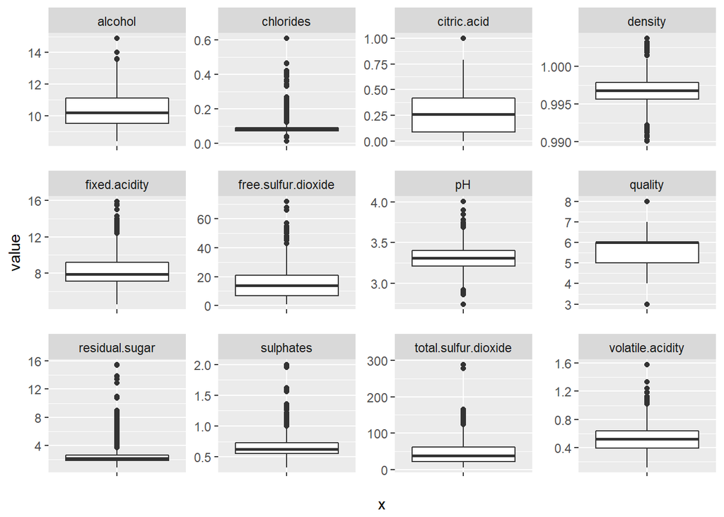

Let’s look at each variable individually.

Alcohol has a median of 10.20 and has a range between 8.40 and 14.90.

```
##    Min. 1st Qu.  Median    Mean 3rd Qu.    Max.
##    8.40    9.50   10.20   10.42   11.10   14.90
```

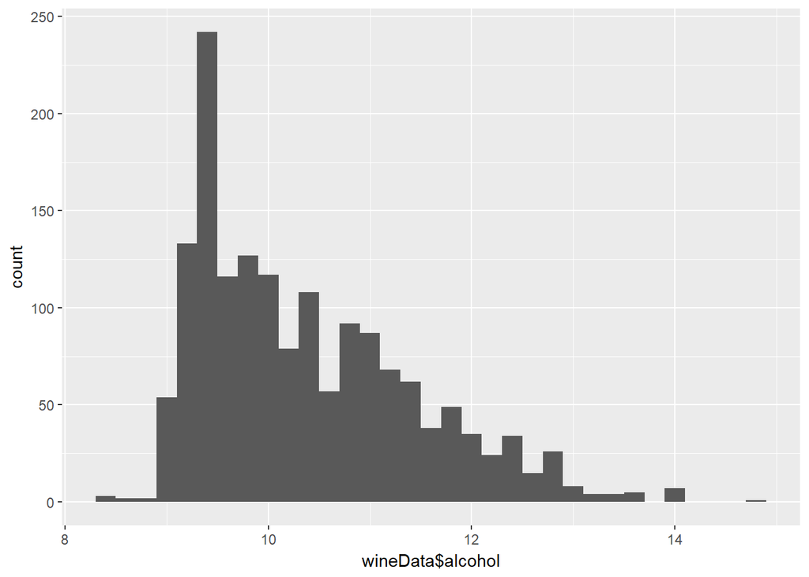

Chlorides has a median of .07900 and has a range between .01200 and .61100.

```
##    Min. 1st Qu.  Median    Mean 3rd Qu.    Max.
## 0.01200 0.07000 0.07900 0.08747 0.09000 0.61100
```

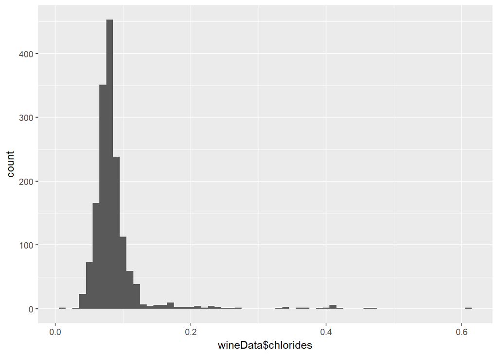

```
##    Min. 1st Qu.  Median    Mean 3rd Qu.    Max.
##   0.000   0.090   0.260   0.271   0.420   1.000
```

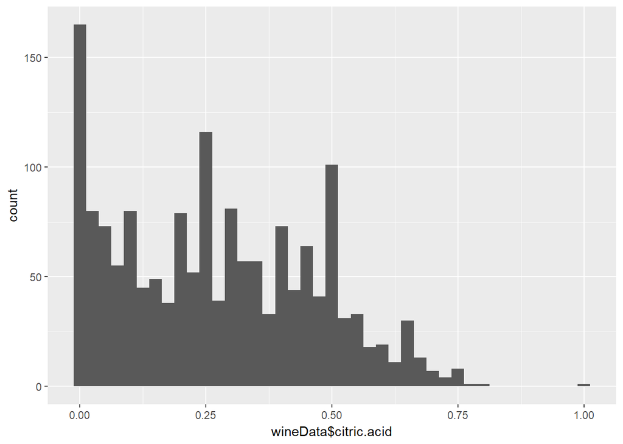

Density doesn’t have much variation with the min being 0.9901 and the max being 1.0037

```
##    Min. 1st Qu.  Median    Mean 3rd Qu.    Max.
##  0.9901  0.9956  0.9968  0.9967  0.9978  1.0037
```

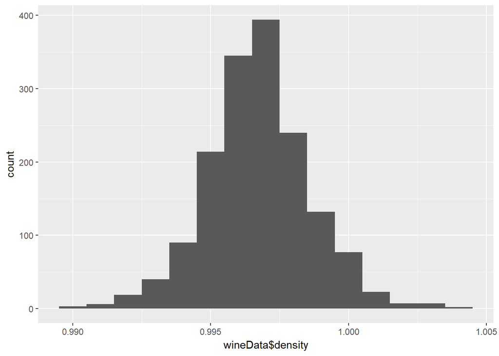

```
##    Min. 1st Qu.  Median    Mean 3rd Qu.    Max.
##    4.60    7.10    7.90    8.32    9.20   15.90
```

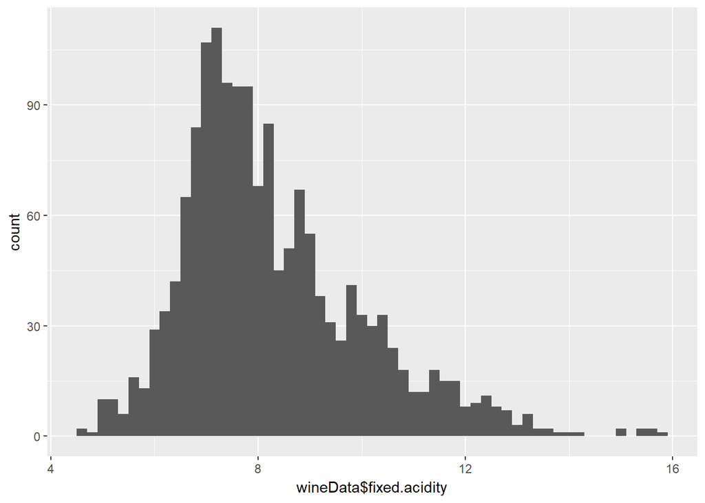

Free Sulfur Dioxide has a median of 14.00 and a range between 1 and 72. The histogram below shows that most wines have free sulfur dioxide levels below 40.

```
##    Min. 1st Qu.  Median    Mean 3rd Qu.    Max.
##    1.00    7.00   14.00   15.87   21.00   72.00
```

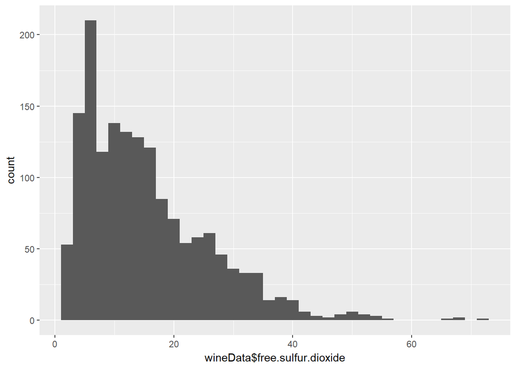

pH has a median of 3.310 and a range of 2.740 to 4.010 and appears to have a normal distribution.

```
##    Min. 1st Qu.  Median    Mean 3rd Qu.    Max.
##   2.740   3.210   3.310   3.311   3.400   4.010
```

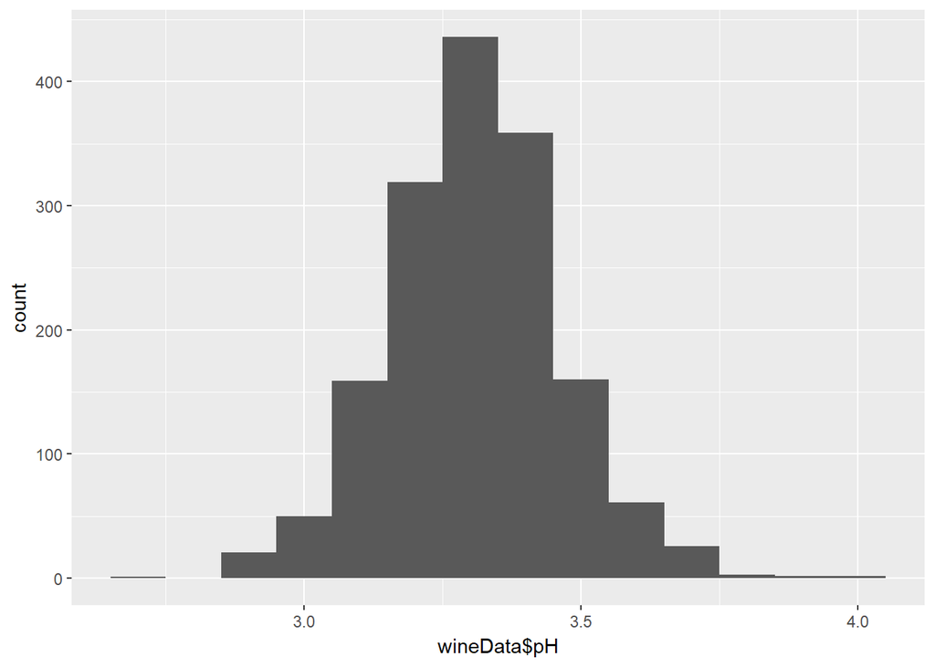

Quality has a median of 6.0 and a range of 3.0 and 8.0 but most of the red wines have a quality score of 5 or 6.

```
##    Min. 1st Qu.  Median    Mean 3rd Qu.    Max.
##   3.000   5.000   6.000   5.636   6.000   8.000
```

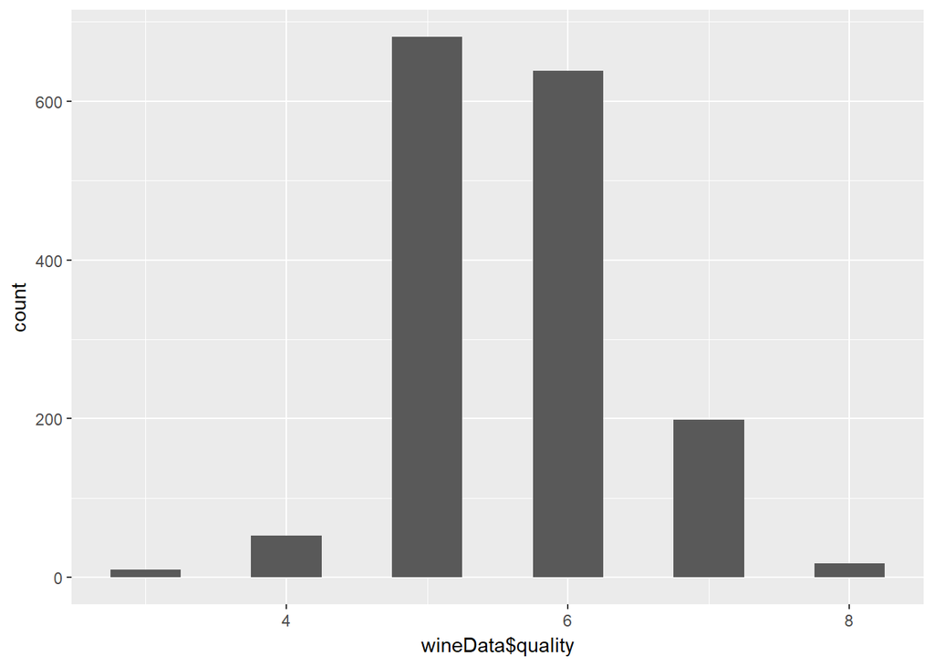

residual.sugar has a median of 2.2 and a range between 0.900 and 15.500 but most data points are between 1 and 4

```
##    Min. 1st Qu.  Median    Mean 3rd Qu.    Max.
##   0.900   1.900   2.200   2.539   2.600  15.500
```

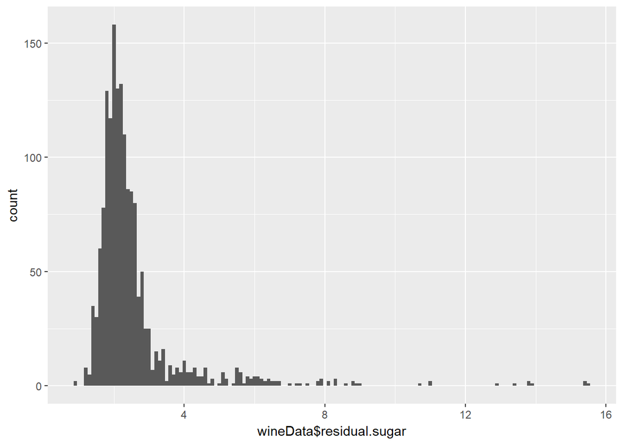

sulphates has a median of 0.6200 and a range of 0.3300 to 2.000

```
##    Min. 1st Qu.  Median    Mean 3rd Qu.    Max.
##  0.3300  0.5500  0.6200  0.6581  0.7300  2.0000
```

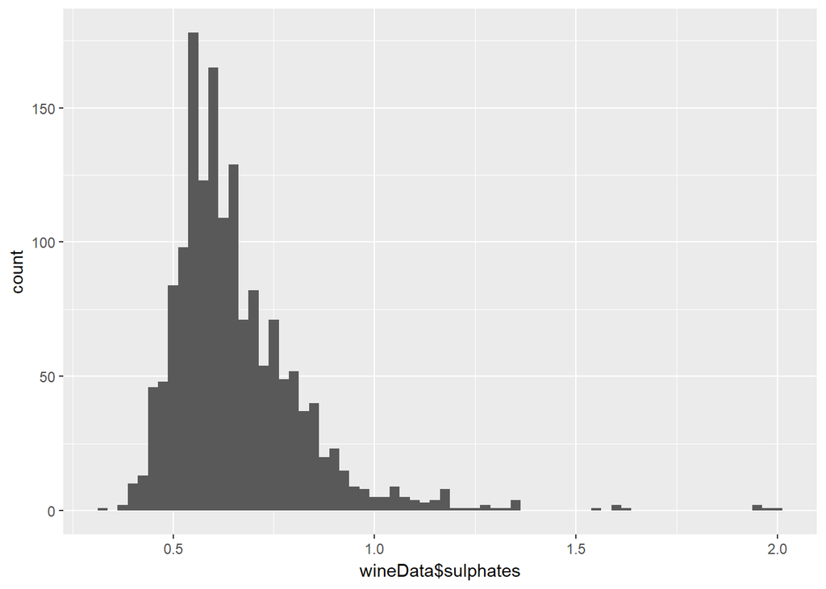

total.sulphur.dioxide has a median of 38.00 and a range of 6.00 to 289.00 with most of the data points being between 0 and 150.

```
##    Min. 1st Qu.  Median    Mean 3rd Qu.    Max.
##    6.00   22.00   38.00   46.47   62.00  289.00
```

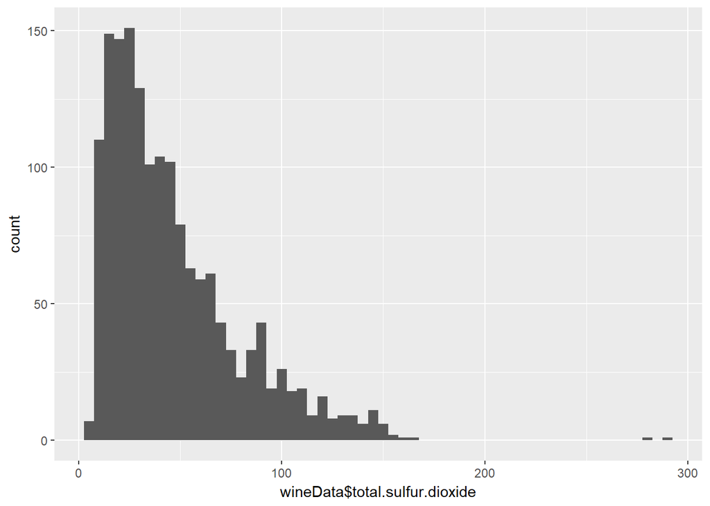

volatile.acidity has a median 0f .5200 and a range between .1200 and 1.58

```
##    Min. 1st Qu.  Median    Mean 3rd Qu.    Max.
##  0.1200  0.3900  0.5200  0.5278  0.6400  1.5800
```

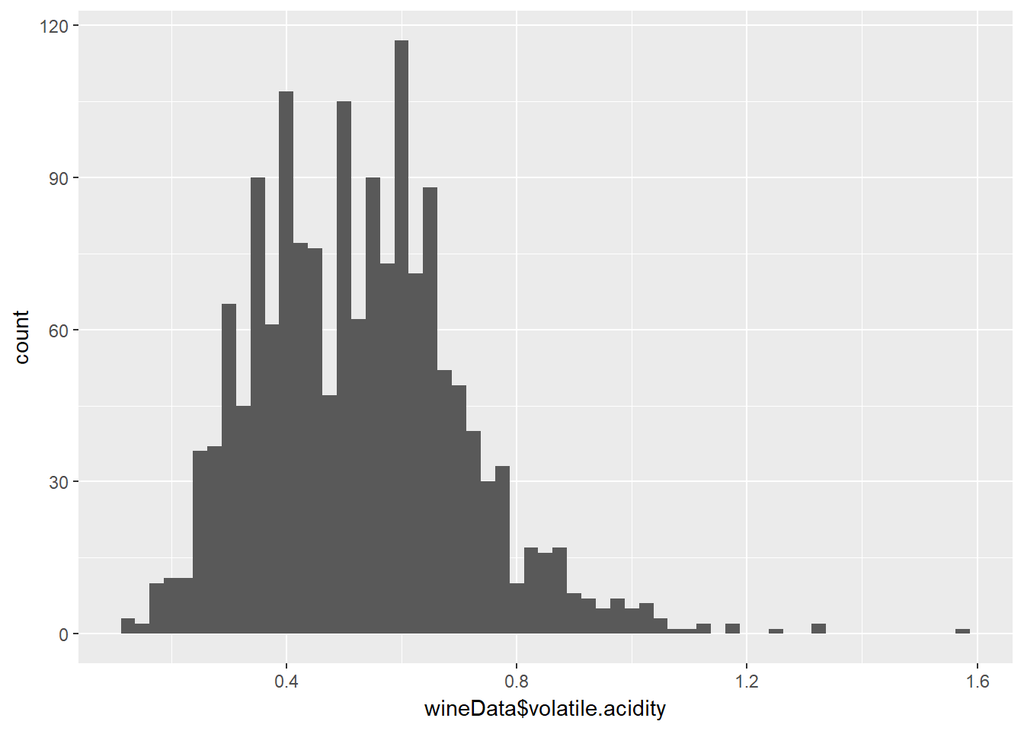

Of the individual histograms above it appears that citric.acid, chlorides, sulphates, and total.sulfur.dioxide do not have a normal distribution and seem to be skewed.

Let’s look a little closer at these variables:

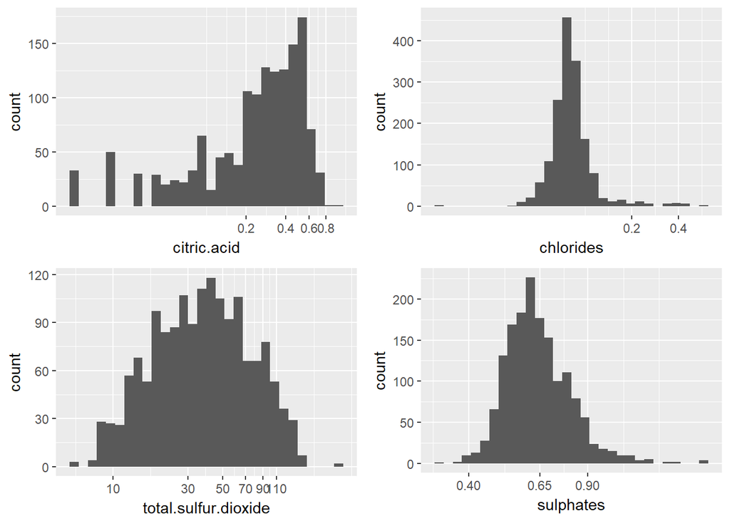

# Univariate Analysis

### What is the structure of your dataset?

All the variables are numeric with quality being the only integer. There are 13 variables and 1599 observations. The variables are as follows:

fixed acidity <- most acids involved with wine or fixed or nonvolatile (doesn’t evaporate readily)

volatile acidity <- the amount of acetic acid in wine

citric acid <- add ‘freshness’ and flavor to wines

residual sugar <- the amount of sugar(gram/liter) remaining after fermentation stops

chlorides <- the amount of salt in the wine

free sulfur dioxide <- the free form of SO2 exists in equilibrium between molecular SO2 (as a dissolved gas) and bisulfite ion

total sulfur dioxide <- amount of free and bound forms of S02

density <- the density of water is close to that of water depending on the percent alcohol and sugar content

pH: describes how acidic or basic a wine is on a scale from 0 (very acidic) to 14 (very basic); most wines are between 3-4 on the pH scale

sulphates <- a wine additive which can contribute to sulfur dioxide gas (S02) levels, wich acts as an antimicrobial and antioxidant

alcohol <- the percent alcohol content of the wine

quality <- score between 0 and 10

### What is/are the main feature(s) of interest in your dataset?

The main feature of interest for this dataset is what variables determines the quality of red wine.

### What other features in the dataset do you think will help support your investigation into your feature(s) of interest?

Understanding which variables have the highest impact in determing quality of red wines.

### Of the features you investigated, were there any unusual distributions? Did you perform any operations on the data to tidy, adjust, or change the form of the data? If so, why did you do this?

In order to tidy the data, I removed the variable “X”" from the dataset because it is an index.

# Bivariate Plots Section

To get some initial guidance about which variables may be correlated to each other let’s look at how the variables correlate to the variable “quality”. As you can see alcohol, sulphates, and volatile.acidity have the highest correlation:

alcohol (0.4762) sulphates (0.2514) volatile.acidity (-0.3906)

```
##                      fixed.acidity volatile.acidity citric.acid
## fixed.acidity           1.00000000     -0.256130895  0.67170343
## volatile.acidity       -0.25613089      1.000000000 -0.55249568
## citric.acid             0.67170343     -0.552495685  1.00000000
## residual.sugar          0.11477672      0.001917882  0.14357716
## chlorides               0.09370519      0.061297772  0.20382291
## free.sulfur.dioxide    -0.15379419     -0.010503827 -0.06097813
## total.sulfur.dioxide   -0.11318144      0.076470005  0.03553302
## density                 0.66804729      0.022026232  0.36494718
## pH                     -0.68297819      0.234937294 -0.54190414
## sulphates               0.18300566     -0.260986685  0.31277004
## alcohol                -0.06166827     -0.202288027  0.10990325
## quality                 0.12405165     -0.390557780  0.22637251
##                      residual.sugar    chlorides free.sulfur.dioxide
## fixed.acidity           0.114776724  0.093705186        -0.153794193
## volatile.acidity        0.001917882  0.061297772        -0.010503827
## citric.acid             0.143577162  0.203822914        -0.060978129
## residual.sugar          1.000000000  0.055609535         0.187048995
## chlorides               0.055609535  1.000000000         0.005562147
## free.sulfur.dioxide     0.187048995  0.005562147         1.000000000
## total.sulfur.dioxide    0.203027882  0.047400468         0.667666450
## density                 0.355283371  0.200632327        -0.021945831
## pH                     -0.085652422 -0.265026131         0.070377499
## sulphates               0.005527121  0.371260481         0.051657572
## alcohol                 0.042075437 -0.221140545        -0.069408354
## quality                 0.013731637 -0.128906560        -0.050656057
##                      total.sulfur.dioxide     density          pH
## fixed.acidity                 -0.11318144  0.66804729 -0.68297819
## volatile.acidity               0.07647000  0.02202623  0.23493729
## citric.acid                    0.03553302  0.36494718 -0.54190414
## residual.sugar                 0.20302788  0.35528337 -0.08565242
## chlorides                      0.04740047  0.20063233 -0.26502613
## free.sulfur.dioxide            0.66766645 -0.02194583  0.07037750
## total.sulfur.dioxide           1.00000000  0.07126948 -0.06649456
## density                        0.07126948  1.00000000 -0.34169933
## pH                            -0.06649456 -0.34169933  1.00000000
## sulphates                      0.04294684  0.14850641 -0.19664760
## alcohol                       -0.20565394 -0.49617977  0.20563251
## quality                       -0.18510029 -0.17491923 -0.05773139
##                         sulphates     alcohol     quality
## fixed.acidity         0.183005664 -0.06166827  0.12405165
## volatile.acidity     -0.260986685 -0.20228803 -0.39055778
## citric.acid           0.312770044  0.10990325  0.22637251
## residual.sugar        0.005527121  0.04207544  0.01373164
## chlorides             0.371260481 -0.22114054 -0.12890656
## free.sulfur.dioxide   0.051657572 -0.06940835 -0.05065606
## total.sulfur.dioxide  0.042946836 -0.20565394 -0.18510029
## density               0.148506412 -0.49617977 -0.17491923
## pH                   -0.196647602  0.20563251 -0.05773139
## sulphates             1.000000000  0.09359475  0.25139708
## alcohol               0.093594750  1.00000000  0.47616632
## quality               0.251397079  0.47616632  1.00000000
```

In addition to comparing the variables to quality, the following pairs also had strong correlation to one another:

free.sulphur.dioxide -> total.sulphur.dioxide (0.7)

citric.acid -> fixed.acidity (0.7)

density-> fixed.acidity (0.7)

The matrix below shows a the relationship between the variables and its respective correlation coefficient.

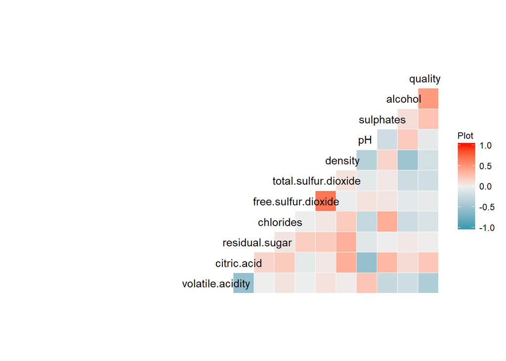

Let’s look at the variables that have the highest correlation to quality

Quality ratings score of very bad, bad, and average have their percent alcohol contents concentrated around 10 whereas a quality category of “excellent” has its percent alcohol concentrated around 12.

As alcohol goes up, quality also goes up.

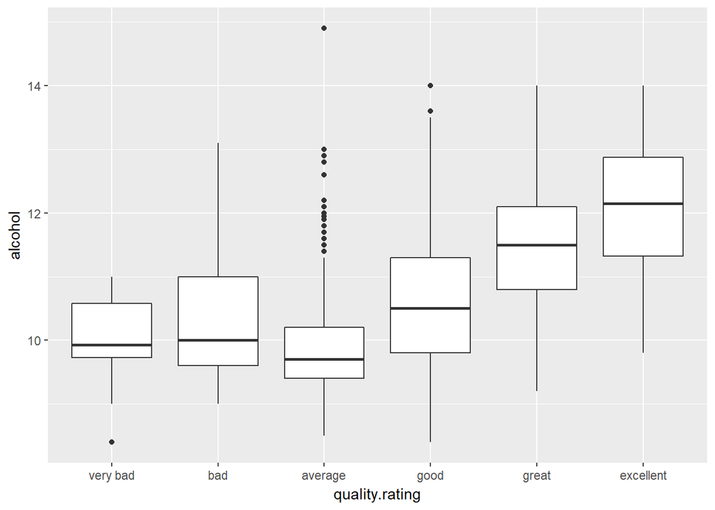

The correlation between quality and volatile.acidity is -0.39055778 which means as volatile.acidity goes down, quality goes up.

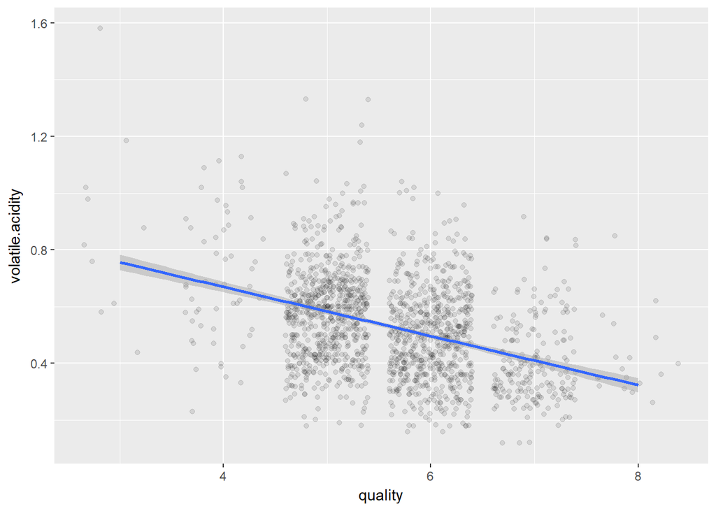

Now let’s take a look at the correlation between quality and sulphates. It has a correlation coefficient of 0.25139708. The graph below shows that as sulphates goes up, qualty goes up but definitely not equal to the incline represented by alcohol content.

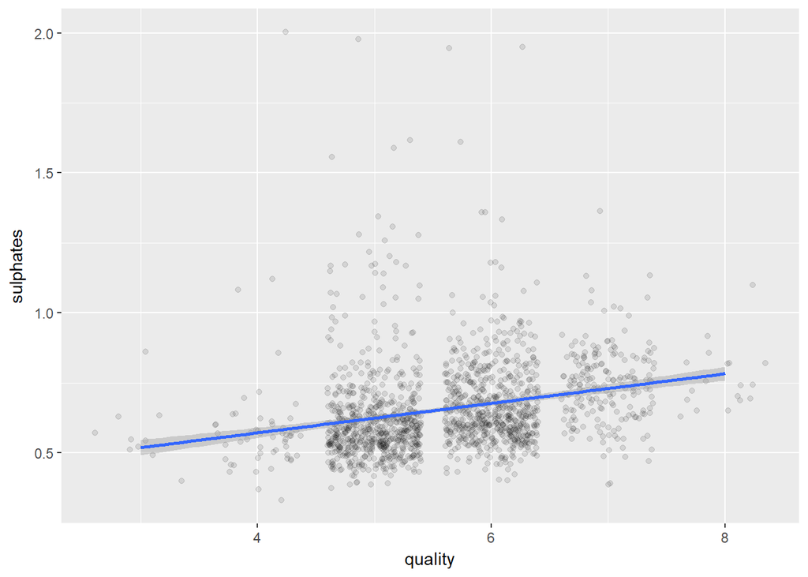

# Bivariate Analysis

### Did you observe any interesting relationships between the other features (not the main feature(s) of interest)?

The relationship of fixed.acidity and volatile acidity on quality was interesting in that one had a positive correlation while the other had a negative correlation.

### What was the strongest relationship you found?

The strongest relationship ,as it relates to quality, was between alcohol and quality although moderate at 0.47616632. Quality in itself is subjective, but alcohol levels are a predictor in whether a red wine will be percieved as having ‘higher’ qualty.

# Multivariate Plots Section

Volatile.acidity and Alcohol seem to have a moderate impact on determining the quality of wine. The combination of higher levels of Alcohol and lower levels of Volatile.acidity are represented in the higher quality wines.

[output not shown]

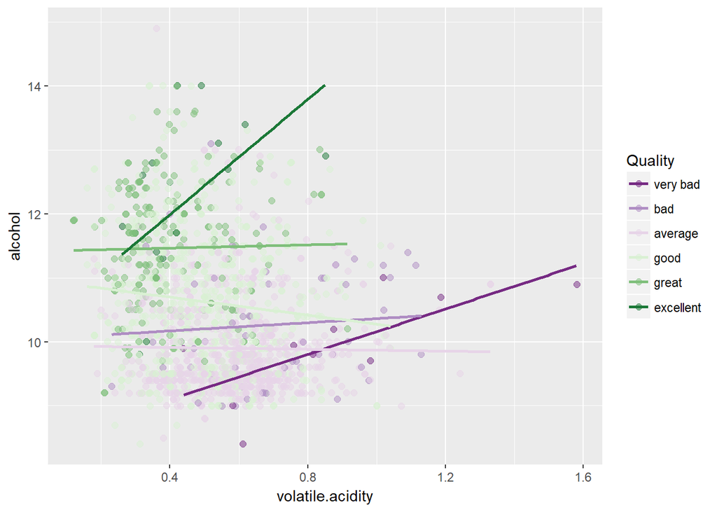

# Multivariate Analysis

### Talk about some of the relationships you observed in this part of the investigation. Were there features that strengthened each other in terms of looking at your feature(s) of interest?

Although my initial interest were whether or not residual.sugar contributed to a higher quality of red wine, the data quickly took me in a different direction. Alcohol quickly rose to the top as one of the predictors of a quality red wine and followed closely by sulphates and volatile acidity.

### Were there any interesting or surprising interactions between features?

The suprising interaction between quality and the other features was that there was no “strong”" correlation between any of the variables. Alcohol had the strongest correlation and that was just 0.47. Which leads me to believe there is no “recipe” for a quality bottle of red wine.

# Final Plots and Summary

### Plot One

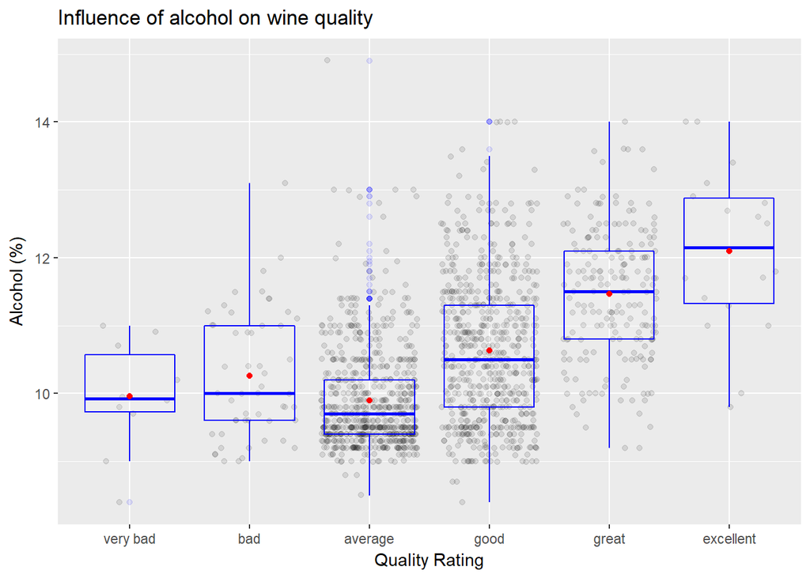

### Description One

The main point this analysis drives home is that as alcohol levels go up, that quality also goes up. This box plot continues to explore that and shows that very bad and bad quality wines have lower alcohol content. The boxplot allows us to see that the average bucket has the lowest alcohol content which is most likely influenced by the large amount of outliers.

### Plot Two

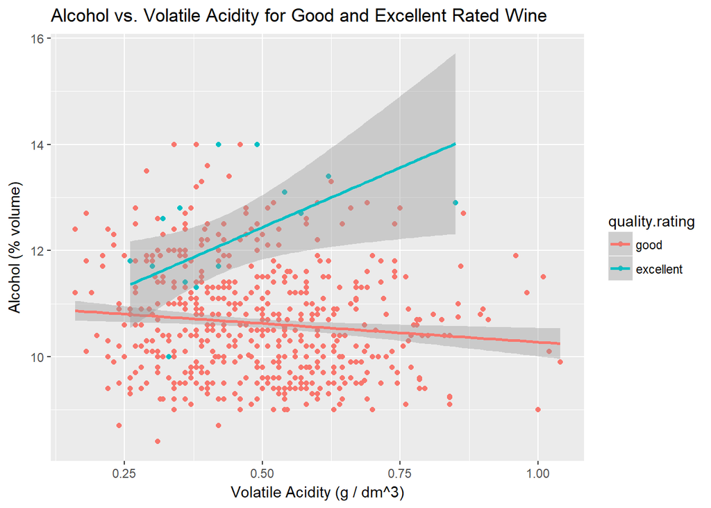

### Description Two

The question is which properties help to achieve a “good”" to “excellent”" rated wine. The answer is an alcohol content betwenn 10 - 12 and volatile acidity levels should be approximately between 0.25 and 0.90.

### Plot Three

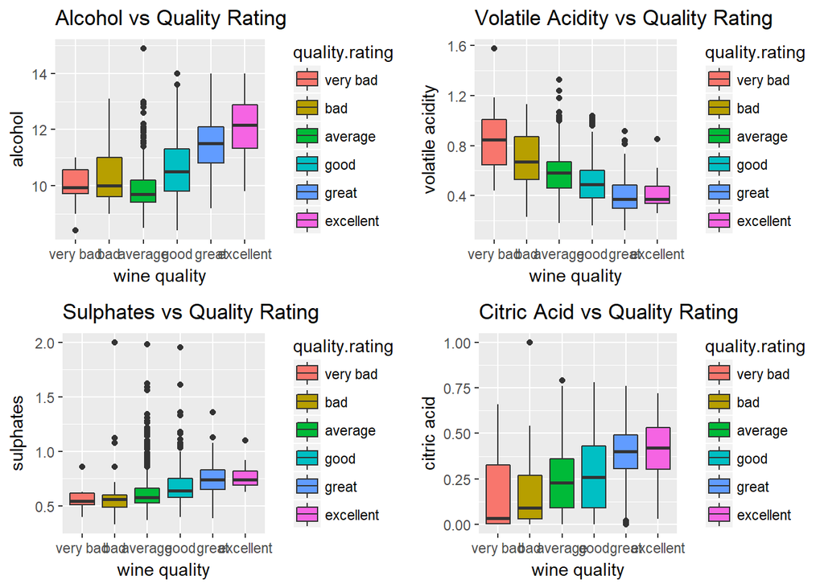

### Description Three

Alcohol, volatile acidity, sulphates, and citric acid have the highest correlation to quality. Quality wines have higher alcohol content than lower quality wines. Volatile acidity decrease as wine quality increases. Sulphate and critic acid increase as wine quality increase.

# Reflection

The red wine data set contains information on the chemical properties of a selection of wines collected in 2009. It also includes a quality rating from 0-10. I started by looking at the individual distributions of the variables, trying to get a feel for each one. The first thing I noticed was the high concentration of wines in the middle ranges of the data, that is, average to good tasting wines. When I looked at each variable individully it showed a normal distribution or a long tailed distribution influenced by outliers.

After exploring the individual variables, I proceded to investigate the relationships between each input variable and its correlation to quality. The data showed that alcohol, sulphates and volatile.acidity had the highest impact on quality. I then explored the impacts of variables on each other and not with quality. The data showed that citric.acid has a strong correlation to fixed.acidity (0.7) and density also has a strong correlation to fixed.acidity (0.7).

For future studies, it would be interesting to analyse a dataset that contains more datapoints in the “very bad”" and “excellent”" range. It would be nice to know if the outcome would be the same if the datset was more varied. I also think it would be interesting to include the price of the wine to determine if this would also contribute to a higher quality rating.